# 1. Rozdelenie pravdepodobnosti

Štatistické metódy vyhodnocovania experimentov

William Brach

23.02.2021

# Príklad 1 (klíčivosť semien)

**Zadanie:** Výrobca garantuje, že klíčivosť semien špeciálnej odrody hrachu je 80%. Záhradkár kúpil 20 semien hrachu. Vypočítajte pravdepodobnosť, že

- všetky semená vyklíčia
- najviac k 1 semien vyklíči
- vyklíči aspoň k−1 semien
- Vypočítajte strednú hodnotu a disperziu
- zostrojte graf rozdelenia pravdepodobnosti **Riešenie:**

```r
k <- 5 # BRACH
n <- 20 # pocet pokusov
p <- 0.8 # pravdepodobnost nastatia jedneho pokusu
```

1. Všetky semená vyklíčia

```r
dbinom(20, size = n, prob = p)
```

```
## [1] 0.01152922
```

2. Najviac k semien vyklíči

```r
pbinom(k, size = n, prob = p)  # pravdepodobnosť úspechu najviac v 5 pokusoch
```

```
## [1] 1.802764e-07
```

3. Vyklíči aspoň k−1 semien.

```r
1-pbinom(3, size = n, prob = p)  # pravdepodobnosť uspechu v aspon 4 (5-1) pokusoch
```

```
## [1] 1
```

4. Vypočítajte strednú hodnotu a disperziu

```r
n*p  # stredna hodnota
```

```
## [1] 16
```

```r
n*p*(1-p)  # disperzia
```

```
## [1] 3.2
```

5. Zostrojte graf rozdelenia pravdepodobnosti

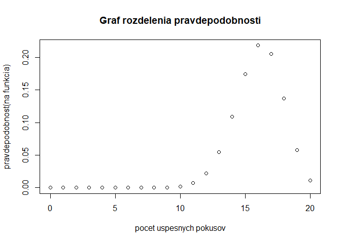

```r
x <- 0:n
plot(x,
     y = dbinom(x, size = n, prob =p),
     xlab = "pocet uspesnych pokusov",
     ylab = "pravdepodobnost(na funkcia)",
     main="Graf rozdelenia pravdepodobnosti"
)
```

# Príklad 2 (pomocou hypergeometrického rozdelenia)

**Zadanie:** Riešte predošlý príklad pomocou hypergeometrického rozdelenia, ak vieme, že záhradkár vyberal zo 400 semien hrachu. Porovnajte grafy rozdelenia pravdepodobnosti.

**Riešenie:**

```r
k <- 5 # BRACH
whiteBalls <- 400 * 0.8 # vypocitame si kolko je dobrych semien hrachu je vo vzorke
blackBalls <- 400 - (400 * 0.8) #vypocime si kolko zlych semien hrachu je vo vzorke
N <- 400 #velkost vzorky
```

1. Všetky semená vyklíčia

```r
dhyper(20, m = whiteBalls, n = blackBalls,  k = 20)  # x = 20 lebo chceme aby vsetkych 20 vybratych vyklicilo
```

```
## [1] 0.01019202
```

2. Najviac k semien vyklíči 1 - phyper(20-5) kvoli tomu aby sme od 1 odcitali aspon 15 vyklicenych

```r
1 - phyper(20-k-1, m = whiteBalls, n = blackBalls,  k = 20)
```

```
## [1] 0.8093063
```

3. Vyklíči aspoň k−1 (4) semien.

```r
phyper(3, m = whiteBalls, n = blackBalls,  k = 20, lower.tail = F )
```

```
## [1] 1
```

4. Vypočítajte strednú hodnotu a disperziu

```r
N <- 400
M <- whiteBalls
n <- 20
n*M/N  # stredna hodnota
```

```
## [1] 16
```

```r
n*M/N*(1-M/N)*(N-n)/(N-1)  # disperzia
```

```
## [1] 3.047619
```

5. Zostrojte graf rozdelenia pravdepodobnosti

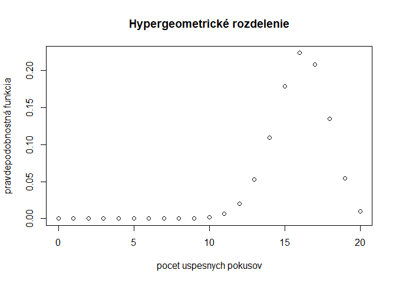

```r
x <- 0:n
plot(x,
     y = dhyper(x, m = whiteBalls, n = blackBalls, k = n),
     xlab = "pocet uspesnych pokusov",
     ylab = "pravdepodobnostná funkcia",
     main="Hypergeometrické rozdelenie"
)
```

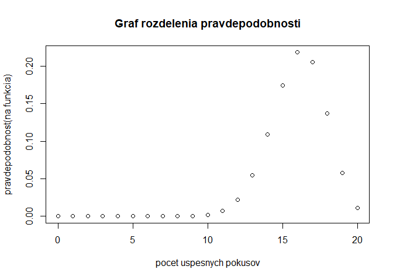

```r
plot(x,
     y = dbinom(x, size = 20, prob =0.8),
     xlab = "pocet uspesnych pokusov",
     ylab = "pravdepodobnost(na funkcia)",
     main="Graf rozdelenia pravdepodobnosti"
)
```